# Online Store - A/B Test Analysis

## I'm a data analyst at a big online store, together with the marketing department, I've compiled a list of hypotheses, I will prioritize these hypotheses, launch an A/B test, and analyze the results, in order to find which hypothesis may help boost revenue.

## First I will explore the data and preprocess it for my further analysis:

```python
import pandas as pd
import numpy as np
import matplotlib.pyplot as plt
import scipy.stats as stats
import seaborn as sns
import plotly.express as px
import random
```

### Hypotheses Dataset:

#### This dataset contains nine hypotheses on boosting an online store's revenue with Reach, Impact, Confidence, and Effort specified for each.

```python
# exploring the whole dataset to get general information
hypotheses = pd.read_csv('/datasets/hypotheses_us.csv')
hypotheses.sample()
```

|  | Hypothesis;Reach;Impact;Confidence;Effort |
| --- | --- |
| 3 | Change the category structure. This will incre... |

#### Using the sample function I see that the columns are not seperated and the columns names are with upper case letters. I will use sep separator to seperate the columns and use str.lower() method to make the strings in the columns to lower case.

```python
hypotheses = pd.read_csv('/datasets/hypotheses_us.csv', sep=';') # using sep separator
hypotheses.sample() #test

hypotheses.columns = hypotheses.columns.str.lower() # changing the columns names to lower case
hypotheses.sample() #test
hypotheses.shape
hypotheses.tail()
hypotheses.head()
```

|  | hypothesis | reach | impact | confidence | effort |
| --- | --- | --- | --- | --- | --- |
| 0 | Add two new channels for attracting traffic. T... | 3 | 10 | 8 | 6 |
| 1 | Launch your own delivery service. This will sh... | 2 | 5 | 4 | 10 |
| 2 | Add product recommendation blocks to the store... | 8 | 3 | 7 | 3 |
| 3 | Change the category structure. This will incre... | 8 | 3 | 3 | 8 |
| 4 | Change the background color on the main page. ... | 3 | 1 | 1 | 1 |

```python
hypotheses.info(memory_usage='deep')
```

```
<class 'pandas.core.frame.DataFrame'>
RangeIndex: 9 entries, 0 to 8
Data columns (total 5 columns):
hypothesis    9 non-null object
reach         9 non-null int64
impact        9 non-null int64
confidence    9 non-null int64
effort        9 non-null int64
dtypes: int64(4), object(1)
memory usage: 1.6 KB
```

- By using the info() method, I've found that the dataset has 5 columns and 9 rows.
- There are no missing values in any of the columns.
- All of the columns datatypes are correct and don't need to be changed.

```python
print(hypotheses.duplicated().sum()) #searching for duplicated rows
hypotheses.describe()
```

```
0
```

|  | reach | impact | confidence | effort |
| --- | --- | --- | --- | --- |
| count | 9.000000 | 9.000000 | 9.000000 | 9.000000 |
| mean | 4.777778 | 4.777778 | 5.555556 | 4.888889 |
| std | 3.153481 | 3.192874 | 3.045944 | 2.803767 |
| min | 1.000000 | 1.000000 | 1.000000 | 1.000000 |
| 25% | 3.000000 | 3.000000 | 3.000000 | 3.000000 |
| 50% | 3.000000 | 3.000000 | 7.000000 | 5.000000 |
| 75% | 8.000000 | 7.000000 | 8.000000 | 6.000000 |
| max | 10.000000 | 10.000000 | 9.000000 | 10.000000 |

- There are no duplicated rows in the dataset.
- Using the describe() method, I've discovered these findings:
  - "reach" column - represents how many users will be affected by the update/hypothesis we want to test, on a scale of one to ten. we can see that the min value is 1 and the max value is 10 which means there are hypothesis in this datasets that has an affect on a lot of users while some have the least amount of affect on the user's reach. we can also see that the mean is a bit higher than the median, this means that there are more hypotheses that have a higher score of reach and affect the mean value.
  - "impact" column - represents how strongly this update/hypothesis will affect the users, their experience and satisfaction, on a scale of one to ten. as we can see, the values of the "reach" column and this column are the same, the min value is 1 and max value is 10, and the mean is higher than the median as well which can tell us that there are more hypotheses that have a higher score of impact and affect the mean value.
  - "confidence" column - represents how sure we are that our hypothesis will affect them in this way, on a scale of one to ten. Based on the describe table we can see that the min value is 1 and the max is 9, that means there are hypotheses that the level of confidence is low and hypotheses with a much higher level of confidence. we can also see that the mean value is lower than the median, we can assume that there are more hypotheses that has a lower level of confidence that affect the mean value.
  - "effor" column - represents how much will it costs to test the hypothesis, on a scale of one to ten. as we can see, the min value is 1 and the max value is 10 which means, that there are hypotheses with a small amount of resources and hypotheses with higher amount of resources. the mean and median value are pretty close to each other (4.88 - 5), which means that the distribution is normal and there are not extreme outliers.

```python
# exploring coulmns individually to look for unique/missing/duplicated/abnormal values
hypotheses['hypothesis'].value_counts()
```

```
Launch your own delivery service. This will shorten delivery time                                                         1
Change the category structure. This will increase conversion since users will find the products they want more quickly    1
Add a customer review page. This will increase the number of orders                                                       1
Add a subscription form to all the main pages. This will help you compile a mailing list                                  1
Show banners with current offers and sales on the main page. This will boost conversion                                   1
Add two new channels for attracting traffic. This will bring 30% more users                                               1
Launch a promotion that gives users discounts on their birthdays                                                          1
Add product recommendation blocks to the store's site. This will increase conversion and average purchase size            1
Change the background color on the main page. This will increase user engagement                                          1
Name: hypothesis, dtype: int64
```

- As we can see the "hypothesis" column represents the hypotheses that we want to check, each hypothesis has the update/change that it will make and how we assume it will affect the product.
- For example, "Change the background color on the main page." - the update that we want to check and "This will increase user engagement" what we think will happend due to the update/change.

### After examining the Hypotheses dataset, I didn't find missing values/abnormal values or patterns, duplicated rows or datatypes that need to be change, therefore I'm moving to the next dataset.

### Orders Dataset:

#### This dataset contains information about the stores orders - order identifier, user or identifier who placed the order, date, revenue from the order, and the A/B test group that the user belongs to.

```python
# exploring the whole dataset to get general information
orders = pd.read_csv('/datasets/orders_us.csv')
orders.sample()
orders.shape
orders.tail()
orders.head()
```

|  | transactionId | visitorId | date | revenue | group |
| --- | --- | --- | --- | --- | --- |
| 0 | 3667963787 | 3312258926 | 2019-08-15 | 30.4 | B |
| 1 | 2804400009 | 3642806036 | 2019-08-15 | 15.2 | B |
| 2 | 2961555356 | 4069496402 | 2019-08-15 | 10.2 | A |
| 3 | 3797467345 | 1196621759 | 2019-08-15 | 155.1 | B |
| 4 | 2282983706 | 2322279887 | 2019-08-15 | 40.5 | B |

```python
orders.info(memory_usage='deep')
```

```
<class 'pandas.core.frame.DataFrame'>
RangeIndex: 1197 entries, 0 to 1196
Data columns (total 5 columns):
transactionId    1197 non-null int64
visitorId        1197 non-null int64
date             1197 non-null object
revenue          1197 non-null float64
group            1197 non-null object
dtypes: float64(1), int64(2), object(2)
memory usage: 174.3 KB
```

- By using the info() method, I've found that there are 5 columns and 1197 rows.
- There are no missing values in the dataset.
- The "date" column that represetns the date of the order is an object datatype and needs to be changed to datetime64 datatype.
- By using memory_usage='deep', we can see that the dataset is pretty big (174.3 KB), I will change columns data types in order to optimize the dataset and make it smaller to work with.

#### Optimizing the dataset

```python
#--changing the "date" datatype--#
orders['date'] =  pd.to_datetime(orders['date'], format="%Y-%m-%d")
orders.info(memory_usage='deep') #test (105.3 KB)
```

```
<class 'pandas.core.frame.DataFrame'>
RangeIndex: 1197 entries, 0 to 1196
Data columns (total 5 columns):
transactionId    1197 non-null int64
visitorId        1197 non-null int64
date             1197 non-null datetime64[ns]
revenue          1197 non-null float64
group            1197 non-null object
dtypes: datetime64[ns](1), float64(1), int64(2), object(1)
memory usage: 105.3 KB
```

- By changing the "date" column datatype, using the pd.to_datetime method and the correct format "%Y-%m-%d", we reduced the dataset from 174.3 KB to 105.3 KB

```python
#----saving the new dataset optimization----#

orders = pd.read_csv('/datasets/orders_us.csv',
                  parse_dates=['date'])
orders.info(memory_usage='deep') #test
```

```
<class 'pandas.core.frame.DataFrame'>
RangeIndex: 1197 entries, 0 to 1196
Data columns (total 5 columns):
transactionId    1197 non-null int64
visitorId        1197 non-null int64
date             1197 non-null datetime64[ns]
revenue          1197 non-null float64
group            1197 non-null object
dtypes: datetime64[ns](1), float64(1), int64(2), object(1)
memory usage: 105.3 KB
```

```python
print(orders.duplicated().sum()) #searching for duplicated rows
orders.describe()
```

```
0
```

|  | transactionId | visitorId | revenue |
| --- | --- | --- | --- |
| count | 1.197000e+03 | 1.197000e+03 | 1197.000000 |
| mean | 2.155621e+09 | 2.165960e+09 | 131.491646 |
| std | 1.229085e+09 | 1.236014e+09 | 603.004729 |
| min | 1.062393e+06 | 5.114589e+06 | 5.000000 |
| 25% | 1.166776e+09 | 1.111826e+09 | 20.800000 |
| 50% | 2.145194e+09 | 2.217985e+09 | 50.200000 |
| 75% | 3.237740e+09 | 3.177606e+09 | 130.400000 |
| max | 4.293856e+09 | 4.283872e+09 | 19920.400000 |

- There are no douplicated rows in the dataset.
- Using the describe() method, we can see that the min revenue is 5 and the max revenue is 19920.4. we can also see that the mean value is significantly higher than the median (131.49 - 50), which means there are a lot of orders where their revenue was extremely higher than other orders, these revenue orders are outliers values that affect the mean value and therefore we can see that the standard deviation is higher as well.

```python
print(orders['date'].value_counts())
orders['date'].value_counts().mean()
```

```
2019-08-05    48
2019-08-14    47
2019-08-12    47
2019-08-06    46
2019-08-15    46
2019-08-28    45
2019-08-01    45
2019-08-27    44
2019-08-02    44
2019-08-19    43
2019-08-08    43
2019-08-29    42
2019-08-07    42
2019-08-26    41
2019-08-09    41
2019-08-22    41
2019-08-23    40
2019-08-03    40
2019-08-10    39
2019-08-16    38
2019-08-21    37
2019-08-30    35
2019-08-13    35
2019-08-04    33
2019-08-20    32
2019-08-31    32
2019-08-24    31
2019-08-11    26
2019-08-18    26
2019-08-17    24
2019-08-25    24
Name: date, dtype: int64
```

```
38.61290322580645
```

- By using the value_counts() method on the 'date' column, we can see that the orders are all from August 2019 and that there's on average 38 orders in every date of the dataset.

```python
orders['group'].value_counts()
```

```
B    640
A    557
Name: group, dtype: int64
```

#### When I checked the "group" column, I've noticed that there are more users in the B group (640) than the A group (557). I believe that there were two possible reason for that:

#### 1. Tech problem that assigned both letters to one user, even though the user saw only one version of the product.

#### 2. The user indeed saw 2 versions of the app/product, but we still have to delete this user from the data cause we don't know what exactly influenced their behaviour.

#### Therefore, I will get rid of the users that appear in both groups to get a more accurate analysis.

```python
#----checking to see if there are users in both groups----#

# checking in how many groups each user
users_group = orders.groupby('visitorId').agg({'group':'nunique'})
users_group #test

# creating new dataset with users in only one group
user_one_group = users_group.query('group <= 1')
user_one_group #test

# creating a new dataset based on the dataset of users in only one group
orders = orders[orders['visitorId'].isin(user_one_group.index)]
orders['group'].value_counts() #test
```

```
B    548
A    468
Name: group, dtype: int64
```

### I still have a difference between the sizes of each group. I will create an equal samle size for both groups when I'll test their statistical significance parts, but for now I'll leave it like that.

### After examining the Orders dataset, I optimized the dataset by changing the necessary columns datatypes, I didn't find missing values or duplicated rows, therefore I'm moving to the next dataset.

### Visits Dataset:

#### This dataset contains the date, the number of visits on the date specified in the A/B test group specified.

```python
visits = pd.read_csv('/datasets/visits_us.csv')
visits.sample()
visits.shape
visits.tail()
visits.head()
```

|  | date | group | visits |
| --- | --- | --- | --- |
| 0 | 2019-08-01 | A | 719 |
| 1 | 2019-08-02 | A | 619 |
| 2 | 2019-08-03 | A | 507 |
| 3 | 2019-08-04 | A | 717 |
| 4 | 2019-08-05 | A | 756 |

```python
visits.info(memory_usage='deep')
```

```
<class 'pandas.core.frame.DataFrame'>
RangeIndex: 62 entries, 0 to 61
Data columns (total 3 columns):
date      62 non-null object
group     62 non-null object
visits    62 non-null int64
dtypes: int64(1), object(2)
memory usage: 8.2 KB
```

- By using the info() method, I've found that the dataset has 3 columns and 62 rows.
- There are no missing values in any of the columns.
- I've noticed that the "date" column datatype is an object type and needs to be changed to datatime64, since it presents the date.
- By converting the "date" column datatype, I will also optimize the dataset and reduce its memory usage.

#### Optimizing the dataset

```python
#--changing the "date" datatype--#
visits['date'] =  pd.to_datetime(visits['date'], format="%Y-%m-%d")

visits = pd.read_csv('/datasets/visits_us.csv',
                  parse_dates=['date'])
visits.info(memory_usage='deep') #test
```

```
<class 'pandas.core.frame.DataFrame'>
RangeIndex: 62 entries, 0 to 61
Data columns (total 3 columns):
date      62 non-null datetime64[ns]
group     62 non-null object
visits    62 non-null int64
dtypes: datetime64[ns](1), int64(1), object(1)
memory usage: 4.6 KB
```

- By changing the "date" column datatype, using the pd.to_datetime methods, I reduced the dataset from 8.2 KB to 4.6 KB

```python
print(visits.duplicated().sum()) #searching for duplicated rows
visits.describe()
```

```
0
```

|  | visits |
| --- | --- |
| count | 62.000000 |
| mean | 607.290323 |
| std | 114.400560 |
| min | 361.000000 |
| 25% | 534.000000 |
| 50% | 624.500000 |
| 75% | 710.500000 |
| max | 770.000000 |

- There are no duplicated rows in the dataset.
- By using the describe method we can see that every date has around 607-624 visits. the highest number of visits is 770 and the lower number of visits is 361.
- The mean and median values are pretty close to each other (607-624), which means that the distribution is normal and there are not extreme outliers.

```python
visits['date'].value_counts()
visits['group'].value_counts()
```

```
B    31
A    31
Name: group, dtype: int64
```

# Conclusion - Exploring and preprocessing the data

In this step, I've optimized the datasets in order to avoid issues regarding large volume of data, and changed the necessary columns data types:

### Hypotheses Dataset:

**General Information:**

- The number of rows: 9.
- The number of columns: 5.
- Each row represents a hypothesis on boosting an online store's revenue with Reach, Impact, Confidence, and Effort specified for each.
- There are no missing values in this dataset.

**Duplicated Rows:**

- By using the duplicated() and sum() methods I found out that there aren't duplicated rows in the dataset.

**Optimizing data and changing data types**

- Using the sample function I saw that the columns were not separated and the names of the columns were with upper case letters. I used sep separator to separate the columns and used str.lower() method to make the strings in the columns to lower case.
- All of the datatypes of the columns are correct and don't need to be changed.

**Popular Values:**

- Using the describe() method, I've discovered these findings:
  - "reach" column - represents how many users will be affected by the update/hypothesis we want to test, on a scale of one to ten. we can see that the min value is 1 and the max value is 10 which means there are hypotheses in this dataset that has an effect on a lot of users while some have the least amount of effect on the user's reach. we can also see that the mean is a bit higher than the median, this means that there are more hypotheses that have a higher score of reach and affect the mean value.
  - "impact" column - represents how strongly this update/hypothesis will affect the users, their experience, and satisfaction, on a scale of one to ten. as we can see, the values of the "reach" column and this column are the same, the min value is 1 and max value is 10, and the mean is higher than the median as well which can tell us that there are more hypotheses that have a higher score of impact and affect the mean value.
  - "confidence" column - represents how sure we are that our hypothesis will affect them in this way, on a scale of one to ten. Based on the describe table we can see that the min value is 1 and the max is 9, which means there are hypotheses that the level of confidence is low and hypotheses with a much higher level of confidence. we can also see that the mean value is lower than the median, we can assume that there are more hypotheses that have a lower level of confidence that affect the mean value.
  - "effort" column - represents how much will it costs to test the hypothesis, on a scale of one to ten. as we can see, the min value is 1 and the max value is 10 which means, that there are hypotheses with a small number of resources and hypotheses with higher amount of resources. the mean and median values are pretty close to each other (4.88 - 5), which means that the distribution is normal and there are no extreme outliers.

### Orders Dataset:

**General Information:**

- The number of rows: 1197.
- The number of columns: 5.
- Each row represents an order - order identifier, user or identifier who placed the order, date, revenue from the order, and the A/B test group that the user belongs to.
- There are no missing values in this dataset.

**Duplicated Rows:**

By using the duplicated() and sum() methods I found out that there aren't duplicated rows in the dataset.

**Optimizing data and changing data types**

- The "date" column that represents the date of the order had an object datatype and changed to datetime64 datatype.
- By using memory_usage='deep', we saw that the dataset is pretty big (174.3 KB), I changed the "date" columns data type, in order to optimize the dataset and made it smaller to work with.
- By changing the "date" column datatype we reduced the dataset from 174.3 KB to 105.3 KB.
- Using the describe() method, we can see that the min revenue is 5 and the max revenue is 19920.4. we can also see that the mean value is significantly higher than the median (131.49 - 50), which means there are a lot of orders where their revenue was extremely higher than other orders, these revenue orders are outliers values that affect the mean value and therefore we can see that the standard deviation is higher as well.
- When I checked the "group" column, I've noticed that there are more users in the B group (640) than the A group (557). I believe that there were two possible reasons for that:
  1. Tech problem that assigned both letters to one user, even though the user saw only one version of the product.
  2. The user indeed saw 2 versions of the app/product, but we still have to delete this user from the data cause we don't know what exactly influenced their behavior.
- Therefore, I will get rid of the users that appear in both groups to get a more accurate analysis.

**Popular Values:**

- By using the value_counts() method on the 'date' column, we can see that the orders are all from August 2019 and that there are on average 38 orders in every date of this dataset.

### Visits Dataset:

**General Information:**

- The number of rows: 62.
- The number of columns: 3.
- Each row represents the date, the number of visits on the date specified in the A/B test group specified.
- There are no missing values in the dataset.

**Duplicated Rows:**

By using the duplicated() and sum() methods I found out that there aren't duplicated rows in the dataset.

**Optimizing data and changing data types**

- I've noticed that the "date" column datatype is an object type and needed to be changed to datatime64, since it presents the date.
- By converting the "date" column datatype, I optimized the dataset and reduce its memory usage.

**Popular Values:**

- By using the describe method we can see that every date has around 607-624 visits. the highest number of visits is 770 and the lower number of visits is 361.
- The mean and median values are pretty close to each other (607-624), which means that the distribution is normal and there are not extreme outliers.

## After exploring and preprocessing the datasets, I will start by prioritizing the hypotheses

# Part 1. Prioritizing Hypotheses

### Applying the ICE framework to prioritize hypotheses. Sort them in descending order of priority

```python
# calculating the ICE parameter
hypotheses['ICE'] = hypotheses['impact'] * hypotheses['confidence'] / hypotheses['effort']

# sorting the hypotheses in descending order
hypotheses_ICE = hypotheses.loc[:,['hypothesis','ICE']].sort_values('ICE', ascending=False).reset_index()

# Building a bar graph
fig = px.bar(hypotheses_ICE, x='index', y='ICE', title='Hypothesis ICE Score')
fig.update_layout(xaxis_title='Hypothesis', yaxis_title='ICE SCORE')
fig.show()

hypotheses_ICE
```

[interactive chart not shown]

|  | index | hypothesis | ICE |
| --- | --- | --- | --- |
| 0 | 8 | Launch a promotion that gives users discounts ... | 16.200000 |
| 1 | 0 | Add two new channels for attracting traffic. T... | 13.333333 |
| 2 | 7 | Add a subscription form to all the main pages.... | 11.200000 |
| 3 | 6 | Show banners with current offers and sales on ... | 8.000000 |
| 4 | 2 | Add product recommendation blocks to the store... | 7.000000 |
| 5 | 1 | Launch your own delivery service. This will sh... | 2.000000 |
| 6 | 5 | Add a customer review page. This will increase... | 1.333333 |
| 7 | 3 | Change the category structure. This will incre... | 1.125000 |
| 8 | 4 | Change the background color on the main page. ... | 1.000000 |

### Conclusion - Applying the ICE framework to prioritize the hypotheses:

- The ICE framework can rank which hypotheses are the most promising.
- It is calculated by the impact (how strongly this update/hypothesis will affect the users) **multiply** by the confidence (how sure we are that our hypothesis will affect them in this way), **divided** by the effort (how much will it costs to test the hypothesis).
- I've added a new column to the dataset that calculated the ICE and sorted the hypotheses by their ICE score.
- I've built a bar graph displaying the results by using the index of each hypothesis to represent it.
- As we can see the most promising hypotheses are 8, 0, and 7. Their ICE score is the highest, which means each of these hypotheses (8, 0, and 7) has a big impact on the user experience, is backed up by solid research and evidence, and requires minimal effort to build.

**The most promising hypotheses - based on ICE score:**

1. #8 - Launch a promotion that gives users discounts on their birthdays.
2. #0 - Add two new channels for attracting traffic. This will bring 30% more users.
3. #7 - Add a subscription form to all the main pages. This will help you compile a mailing list.

### Applying the RICE framework to prioritize hypotheses. Sort them in descending order of priority

```python
# calculating the RICE parameter
hypotheses['RICE'] = hypotheses['reach'] * hypotheses['impact'] * hypotheses['confidence'] / hypotheses['effort']

# sorting the hypotheses in descending order
hypotheses_RICE = hypotheses.loc[:,['hypothesis', 'RICE']].sort_values('RICE', ascending=False).reset_index()

# Building a bar graph
fig = px.bar(hypotheses_RICE, x='index', y='RICE', title='Hypothesis RICE Score')
fig.update_layout(xaxis_title='Hypothesis', yaxis_title='RICE SCORE')
fig.show()

hypotheses_RICE
```

[interactive chart not shown]

|  | index | hypothesis | RICE |
| --- | --- | --- | --- |
| 0 | 7 | Add a subscription form to all the main pages.... | 112.0 |
| 1 | 2 | Add product recommendation blocks to the store... | 56.0 |
| 2 | 0 | Add two new channels for attracting traffic. T... | 40.0 |
| 3 | 6 | Show banners with current offers and sales on ... | 40.0 |
| 4 | 8 | Launch a promotion that gives users discounts ... | 16.2 |
| 5 | 3 | Change the category structure. This will incre... | 9.0 |
| 6 | 1 | Launch your own delivery service. This will sh... | 4.0 |
| 7 | 5 | Add a customer review page. This will increase... | 4.0 |
| 8 | 4 | Change the background color on the main page. ... | 3.0 |

### Conclusion - Applying the RICE framework to prioritize the hypotheses:

- The RICE framework is another method to rank which hypotheses are the most promising.
- It is calculated by the reach (how many users will be affected by the update/hypothesis) **mutiply** by the impact (how strongly this update/hypothesis will affect the users) **multiply** by the confidence (how sure we are that our hypothesis will affect them in this way), **divided** by the effort (how much will it costs to test the hypothesis).
- I've added a new column to the dataset that calculated the RICE and sorted the hypotheses by their RICE score.
- I've built a bar graph displaying the results by using the index of each hypothesis to represent it.
- As we can see the most promising hypotheses based on RICE score are 7, 2, 0, and 6. Their RICE score is the highest, which means each of these hypotheses (7,2,0 and 6) has a lot of reach, a big impact on the user experience, is backed up by solid research and evidence, and requires minimal effort to build.

**The most promising hypotheses - based on RICE score:**

1. #7 - Add a subscription form to all the main pages. This will help you compile a mailing list.
2. #2 - Add product recommendation blocks to the store's site. This will increase conversion and average purchase size.
3. #0 - Add two new channels for attracting traffic. This will bring 30% more users.
4. #6 - Show banners with current offers and sales on the main page. This will boost conversion.

### Show how the prioritization of hypotheses changes when you use RICE instead of ICE. Provide an explanation for the changes.

```python
import plotly.graph_objects as go
hypotheses_RICE_ICE = hypotheses.loc[:,['hypothesis', 'RICE','ICE']].sort_values('RICE', ascending=False).reset_index()

# Building a bar graph
fig = go.Figure(data=[
    go.Bar(name='ICE SCORE', x=hypotheses_RICE_ICE['index'], y=hypotheses_RICE_ICE['ICE']),
    go.Bar(name='RICE SCORES', x=hypotheses_RICE_ICE['index'], y=hypotheses_RICE_ICE['RICE'])
])
# Change the bar mode
fig.update_layout(barmode='group')
fig.update_layout(xaxis_title='Hypothesis', yaxis_title='ICE AND RICE SCORE')
fig.update_layout(title='ICE AND RICE SCORE FOR EACH HYPOTHESIS')
fig.show()
hypotheses.sort_values('RICE', ascending=False)
```

[interactive chart not shown]

|  | hypothesis | reach | impact | confidence | effort | ICE | RICE |
| --- | --- | --- | --- | --- | --- | --- | --- |
| 7 | Add a subscription form to all the main pages.... | 10 | 7 | 8 | 5 | 11.200000 | 112.0 |
| 2 | Add product recommendation blocks to the store... | 8 | 3 | 7 | 3 | 7.000000 | 56.0 |
| 0 | Add two new channels for attracting traffic. T... | 3 | 10 | 8 | 6 | 13.333333 | 40.0 |
| 6 | Show banners with current offers and sales on ... | 5 | 3 | 8 | 3 | 8.000000 | 40.0 |
| 8 | Launch a promotion that gives users discounts ... | 1 | 9 | 9 | 5 | 16.200000 | 16.2 |
| 3 | Change the category structure. This will incre... | 8 | 3 | 3 | 8 | 1.125000 | 9.0 |
| 1 | Launch your own delivery service. This will sh... | 2 | 5 | 4 | 10 | 2.000000 | 4.0 |
| 5 | Add a customer review page. This will increase... | 3 | 2 | 2 | 3 | 1.333333 | 4.0 |
| 4 | Change the background color on the main page. ... | 3 | 1 | 1 | 1 | 1.000000 | 3.0 |

### After prioritzing the hypotheses, I will continue to my A/B Test.

# Part 2. A/B Test Analysis

### Analyzing the A/B test:

### Graph cumulative revenue by group. Make conclusions and conjectures.

```python
#----Collecting Cumulative Data----#

# building a table with unique paired date-group values and deleting duplicates
dates_groups = orders[['date','group']].drop_duplicates()
dates_groups #test

# Creating a dataset with the required columns and aggregate values from the orders dataset based on dates_groups
orders_aggregated = dates_groups.apply(lambda x: orders[np.logical_and(orders['date'] <= x['date'],
                                                                       orders['group'] == x['group'])].agg(
    {'date' : 'max', 'group' : 'max',
     'transactionId' : pd.Series.nunique, 'visitorId' : pd.Series.nunique,
     'revenue' : 'sum'}), axis=1).sort_values(by=['date','group'])
orders_aggregated #test

# Creating a dataset with the required columns and aggregate values from the visits dataset based on dates_groups
visits_aggregated = dates_groups.apply(lambda x: visits[np.logical_and(visits['date'] <= x['date'],
                                                                           visits['group'] == x['group'])].agg(
    {'date' : 'max', 'group' : 'max',
     'visits' : 'sum'}), axis=1).sort_values(by=['date','group'])
visits_aggregated #test

# merging the two datasets based on the 'date' and 'group' columns
cumulative_data = orders_aggregated.merge(visits_aggregated, left_on=['date', 'group'], right_on=['date', 'group'])
cumulative_data #test

#renaming columns
cumulative_data.columns = ['date', 'group', 'orders', 'buyers', 'revenue', 'visitors']
cumulative_data.head() #test
```

|  | date | group | orders | buyers | revenue | visitors |
| --- | --- | --- | --- | --- | --- | --- |
| 0 | 2019-08-01 | A | 23 | 19 | 2266.6 | 719 |
| 1 | 2019-08-01 | B | 17 | 17 | 967.2 | 713 |
| 2 | 2019-08-02 | A | 42 | 36 | 3734.9 | 1338 |
| 3 | 2019-08-02 | B | 40 | 39 | 3535.3 | 1294 |
| 4 | 2019-08-03 | A | 66 | 60 | 5550.1 | 1845 |

```python
#----Creating the cumulative revenue for each group----#

cumulative_revenue_A = cumulative_data[cumulative_data['group']=='A'][['date','revenue', 'orders']]
cumulative_revenue_A #test

cumulative_revenue_B = cumulative_data[cumulative_data['group']=='B'][['date','revenue', 'orders']]
cumulative_revenue_B.head() #test
```

|  | date | revenue | orders |
| --- | --- | --- | --- |
| 1 | 2019-08-01 | 967.2 | 17 |
| 3 | 2019-08-02 | 3535.3 | 40 |
| 5 | 2019-08-03 | 4606.9 | 54 |
| 7 | 2019-08-04 | 6138.5 | 68 |
| 9 | 2019-08-05 | 7587.8 | 89 |

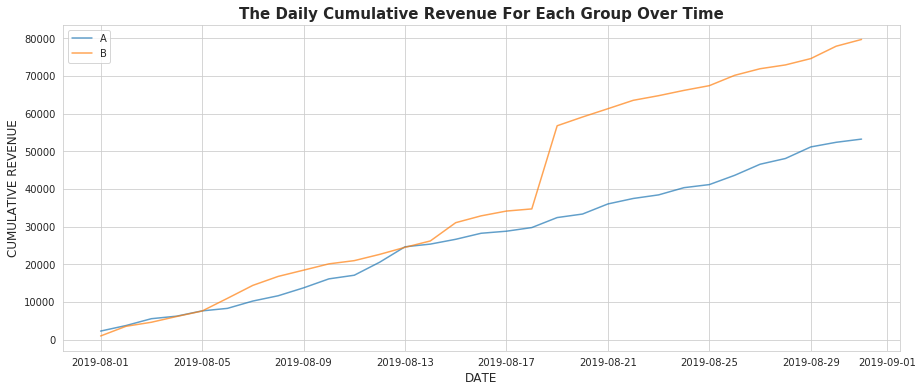

```python
#----Plotting a graph of the cumulative revenue for each group----#

sns.set_style("whitegrid")

fig,ax=plt.subplots(figsize=(15,6))

ax.plot(cumulative_revenue_A['date'], cumulative_revenue_A['revenue'], label='A', alpha=0.7)
ax.plot(cumulative_revenue_B['date'], cumulative_revenue_B['revenue'], label='B', alpha=0.7)

ax.set_title("The Daily Cumulative Revenue For Each Group Over Time", fontsize=15, fontweight="bold")
ax.set_xlabel('DATE', fontsize=12)
ax.set_ylabel('CUMULATIVE REVENUE', fontsize=12)
plt.legend()
plt.show()
```

### Conclusion - Graph cumulative revenue by group:

- In order to plot a graph of cumulative revenue by group I did the following:
  - Created a table with unique paired date-group values and deleted duplicates.
  - Collected the data from both datasets (orders and visits) and aggregated the values from the required columns.
  - Merged the new datasets to one dataset based on date and group and renamed the columns.
  - Created a dataset for each group with the date, revenue, and orders.
  - Using the SNS library I plotted a daily cumulative revenue for both groups.
- As we can see, the two groups started with the same daily revenue, up until 2019-08-05 where group B took the lead insignificantly.
- Then, on 2019-08-13, the groups had the same daily revenue, however after just a few days, group b took the lead again till the rest of the test however this time, its daily revenue got higher and higher, which increased the gap between two groups.
- Overall, revenue was rising steadily in the first half of the test, however on the second half group B tool the lead, with a significant gap between the two groups.
- The revenue spike in group B for the second half of the test implies that there's an increase in the number of sales or a large number of, particularly expensive orders.
- These orders are outliers/extreme values.

### Graph cumulative average order size by group. Make conclusions and conjectures.

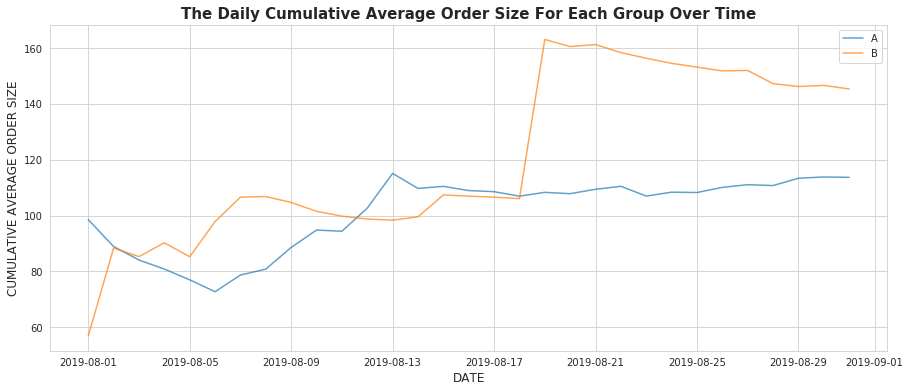

```python
#----Plotting a graph of revenue/orders based on date----#

sns.set_style("whitegrid")

fig,ax=plt.subplots(figsize=(15,6))

ax.plot(cumulative_revenue_A['date'], cumulative_revenue_A['revenue']/cumulative_revenue_A['orders'],
        label='A', alpha=0.7)
ax.plot(cumulative_revenue_B['date'], cumulative_revenue_B['revenue']/cumulative_revenue_B['orders'],
        label='B', alpha=0.7)

ax.set_title("The Daily Cumulative Average Order Size For Each Group Over Time", fontsize=15, fontweight="bold")
ax.set_xlabel('DATE', fontsize=12)
ax.set_ylabel('CUMULATIVE AVERAGE ORDER SIZE', fontsize=12)
plt.legend()
plt.show()
```

### Graph the relative difference in cumulative average order size for group B compared with group A. Make conclusions and conjectures.

#### To show the difference in cumulative average order size between the two groups more obvious, I'll plot a relative difference graph:

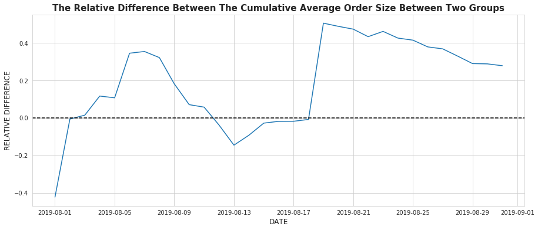

```python
#----Plotting a relative difference graph----#

# merging the datasets into one dataset
merged_cumulative_revenue = cumulative_revenue_A.merge(cumulative_revenue_B,
           left_on='date', right_on='date', how='left', suffixes=['A', 'B'])
merged_cumulative_revenue #test

# plotting a relative difference graph for the average order size
sns.set_style("whitegrid")

fig,ax=plt.subplots(figsize=(15,6))

ax.plot(merged_cumulative_revenue['date'],
(merged_cumulative_revenue['revenueB']/merged_cumulative_revenue['ordersB'])/(merged_cumulative_revenue['revenueA']/merged_cumulative_revenue['ordersA'])-1)

ax.set_title("The Relative Difference Between The Cumulative Average Order Size Between Two Groups", fontsize=15, fontweight="bold")
ax.set_xlabel('DATE', fontsize=12)
ax.set_ylabel('RELATIVE DIFFERENCE', fontsize=12)

# adding the X axis
plt.axhline(y=0, color='black', linestyle='--')

plt.show()
```

### Conclusion - Graph the relative difference in cumulative average order size for group B compared with group A:

- In order to plot the relative difference in cumulative average order size, I did the following:
  - Merged the two datasets of cumulative revenue for each group based on the date and added the letter to each group revenue and orders.
  - I plotted the graph using SNS library by group B cumulative metric (revenue/orders) / group A cumulative metric (revenue/orders) - 1.
  - I assigned the 0 value of the difference as the x-axis.
- As we can see, there are some spikes at the same time periods that the previous graphs showed an increase in revenue and average order size in group B compared to group A.
- This strengthens the conjecture that there was a presence of large, expensive orders, these orders are abnormal / outliers values that need to be analyzed in order to get accurate results of the average order size.

### Calculate each group's conversion rate as the ratio of orders to the number of visits for each day. Plot the daily conversion rates of the two groups and describe the difference. Draw conclusions and make conjectures.

```python
#----Calculating cumulative conversion----#

cumulative_data['conversion'] = cumulative_data['orders'] / cumulative_data['visitors']

# Slicing data based on group
cumulative_data_A = cumulative_data[cumulative_data['group'] == 'A']

cumulative_data_B = cumulative_data[cumulative_data['group'] == 'B']

# Finding the min and max x axes values (for plotting th graph)
min_x = cumulative_data['conversion'].min()
print(min_x)

max_x = cumulative_data['conversion'].max()
print(max_x)
```

```
0.023842917251051893
0.03577235772357724
```

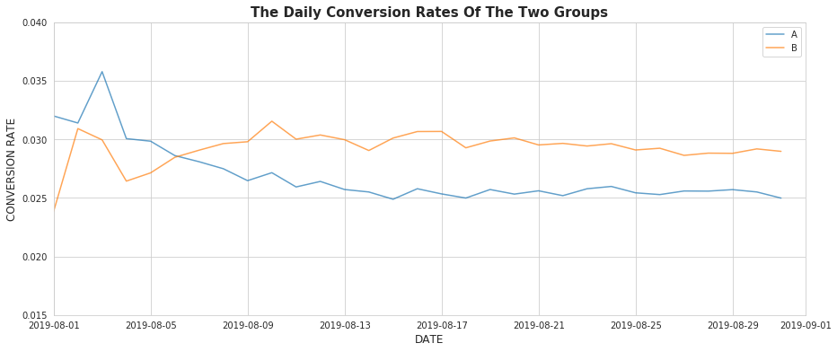

```python
#----Plotting a graph of revenue/orders based on date----#

sns.set_style("whitegrid")

fig,ax=plt.subplots(figsize=(15,6))

ax.plot(cumulative_data_A['date'], cumulative_data_A['conversion'],
        label='A', alpha=0.7)
ax.plot(cumulative_data_B['date'], cumulative_data_B['conversion'],
        label='B', alpha=0.7)

ax.set_title("The Daily Conversion Rates Of The Two Groups", fontsize=15, fontweight="bold")
ax.set_xlabel('DATE', fontsize=12)
ax.set_ylabel('CONVERSION RATE', fontsize=12)
plt.legend()

# using x axes values that are close to the min and max values to get a better visuallization
plt.axis(['2019-08-01', '2019-09-01', 0.015, 0.04])

plt.show()
```

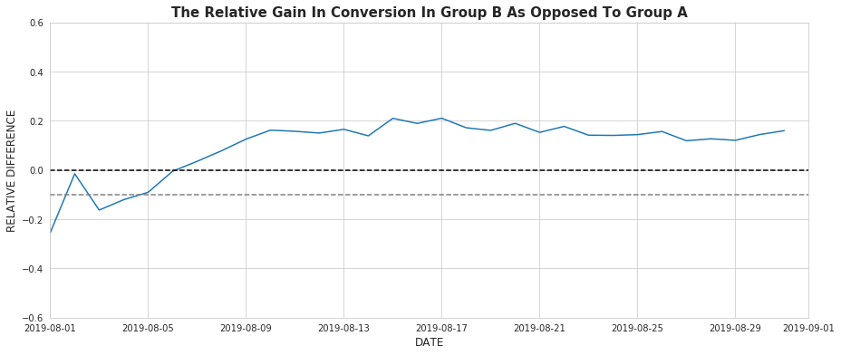

```python
#----Plotting a relative difference in conversion rates----#

# merging the two datasets of both groups
merged_cumulative_conversions = cumulative_data_A[['date','conversion']].merge(cumulative_data_B[['date','conversion']],
                                                    left_on='date', right_on='date', how='left', suffixes=['A', 'B'])

# plotting a relative difference graph in conversion rates
sns.set_style("whitegrid")

fig,ax=plt.subplots(figsize=(15,6))

ax.plot(merged_cumulative_conversions['date'],
        merged_cumulative_conversions['conversionB']/merged_cumulative_conversions['conversionA']-1)
ax.set_title("The Relative Gain In Conversion In Group B As Opposed To Group A", fontsize=15, fontweight="bold")
ax.set_xlabel('DATE', fontsize=12)
ax.set_ylabel('RELATIVE DIFFERENCE', fontsize=12)

# adding the X axis

plt.axhline(y=0, color='black', linestyle='--')
plt.axhline(y=-0.1, color='grey', linestyle='--')
plt.axis(["2019-08-01", '2019-09-01', -0.6, 0.6])

plt.show()
```

### Plot a scatter chart of the number of orders per user. Make conclusions and conjectures.

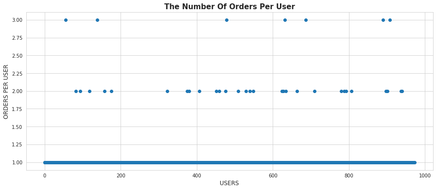

```python
#----Calculating orders per user----#

# Dropping the irrelevant columns and grouping the data by the user and its order
orders_users = orders.drop(['group', 'revenue', 'date'], axis=1).groupby('visitorId', as_index=False).agg(
    {'transactionId' : pd.Series.nunique})

# Renaming the columns
orders_users.columns = ['userId','orders']
orders_users #test


# Plotting a scatter chart
sns.set_style("whitegrid")
fig,ax=plt.subplots(figsize=(15,6))

# determining the values for X
x_values = pd.Series(range(0,len(orders_users)))

ax.scatter(x_values, orders_users['orders'])
ax.set_title("The Number Of Orders Per User", fontsize=15, fontweight="bold")
ax.set_xlabel('USERS', fontsize=12)
ax.set_ylabel('ORDERS PER USER', fontsize=12)

plt.show()
```

### Conclusion - Plot a scatter chart of the number of orders per user:

- In order to plot a scatter chart of the number of orders per user, I did the following:
  - I dropped all the columns that are irrelevant and grouped the visitorId and counted the unique orders - 'transactionId'.
  - I renamed the columns to "userId" and "orders".
  - I plotted a scatter chart based on the numbers of orders per user.
- As we can see, most of the users have only one order, there is a portion of users with 2 orders and a very few users with more than 2 orders.
- These cases, with more than 2 orders may be outliers that also affected the groups' differences.
- As I can assume the typical/common number of orders is 1.
- I'm assuming that group B has more users with more than 2 orders than group A, and therefore group B had higher rates in revenue and conversion.

### Calculate the 95th and 99th percentiles of order prices. Define the point at which a data point becomes an anomaly.

```python
# Calculating the 95th and 99th percentiles with np.percentile method
np.percentile(orders_users['orders'], [95, 99])
```

```
array([1., 2.])
```

### Conclusion - Calculate the 95th and 99th percentiles of order prices. Define the point at which a data point becomes an anomaly

- In order to calculate the 95th and 99th percentiles of order prices, I used the np.percentile method, here are the results:
  - 95th percentile: not more than 5% of the users placed more than one order.
  - 99th percentile: not more than 1% of the users placed more than two orders.
- This means 1% of the users placed more 3 orders, this indicates that indeed users that placed 3 orders are outliers.
- In other words, the point at which a data point becomes an anomaly is 3 orders per user.
- We can also see it in the scatter plot, the number of users with 3 orders is significantly lower than 2 and 1 orders, and to make sure that it indeed an outlier we checked wit the np.percentile method that showed us the percentage of these users with more than 2 orders.
- It will be effective if we will set the limit to 2 orders, to get an accurate result by dropping outliers.
- By calculating the statistical significance, for both filtered data (not more than 2 orders) and the raw data, we'll find out if there's a significant difference between the two groups.

### Find the statistical significance of the difference in conversion between the groups using the raw data. Make conclusions and conjectures.

```python
#----Preparation for finding the statistical significance----#

# Slicing the data by groups and storing the users ID and the number of unique orders

orders_users_A = orders[orders['group']=='A'].groupby('visitorId', as_index=False).agg(
    {'transactionId' : pd.Series.nunique})
orders_users_A.columns = ['userId', 'orders'] #renaming columns

orders_users_B = orders[orders['group']=='B'].groupby('visitorId', as_index=False).agg(
    {'transactionId' : pd.Series.nunique})
orders_users_B.columns = ['userId', 'orders'] #renaming columns

# Creating samples for both groups with users who made orders
# Declaring users without orders as 0 value in the orders column
# Calculating the conversion rate by divide the sum of the orders by the number of users
sample_A = pd.concat([orders_users_A['orders'],
                      pd.Series(0, index=np.arange(visits[visits['group']=='A']['visits'].sum()
                                                   - len(orders_users_A['orders'])), name='orders')],axis=0)

sample_B = pd.concat([orders_users_B['orders'],
                      pd.Series(0, index=np.arange(visits[visits['group']=='B']['visits'].sum()
                                                   - len(orders_users_B['orders'])), name='orders')],axis=0)

# Checking the length of the samples
print(len(sample_B))
print(len(sample_A))
```

```
18916
18736
```

#### As we can see group B has more users than group A. In order to get an accurate results, I decided to sample an equal size of data for both groups. I will sample 18736 for both group (comapring group B to group A), based on the Law of large numbers the bigger a sample size, its mean gets closer to the average of the whole population.

```python
# Comparing the size of group B to group A
sample_B = sample_B.sample(n=18736, replace = False, random_state = 0)
print(len(sample_B))
print(len(sample_A))
```

```
18736
18736
```

#### I decided to use the Mann-Whitney test, based on the graphs that i've plotted, I discovered that there are spikes in conversion rates and average order size, which indicates that there is a significant amount of outliers, that the distributions of the samples are likely to differ. The Mann-Whitney test doesn't make assumptions about how the data is distributed and it's easeir to estimate parameters even with a large number of outliers.

#### Null Hypothesis: There isn't a statistical significant difference in conversion between the groups using raw data.

#### Alternative Hypothesis: There is a statistical significant difference in conversion between the groups using raw data.

```python
# Finding the statistical sigificance

alpha = 0.05 #significance level

# calculating the p-value
p_value = stats.mannwhitneyu(sample_A, sample_B)[1]

print("P VALUE: {0:.3f}".format(p_value))
if (p_value < alpha):
    print("Null hypothesis rejected: the difference is statistically significant")
else:
    print("Failed to reject the null hypothesis: we can't make conclusions about the difference")

# calculating the relative conversion gain for group B
print("The relative conversion gain for group B: {0:.3f}".format(sample_B.mean()/sample_A.mean()-1))
```

```
P VALUE: 0.004
Null hypothesis rejected: the difference is statistically significant
The relative conversion gain for group B: 0.167
```

### Conclusion - Find the statistical significance of the difference in conversion between the groups using the raw data

- In order to find the statistical significance of the difference in conversion, I did the following:
  - I sliced the data by groups, grouped the data by user ID ('visitorId'), and counted the unique orders for each user, in each group.
  - I renamed the columns to "userId" and "orders".
  - I then creating samples for both groups with users who made orders.
  - Declared users without orders as 0 value in the orders column.
  - Calculating the conversion rate by divide the sum of the orders by the number of users
  - I checked to see the length of the samples and found that they are unequal.
  - I decided to created equal sample sizes for both, by comparing group B that had more users to group A. using the sample method with n parameter as the number of rows and used replace= False and random_state = 0, so you can see the same sample as me.
  - I determined the significance level for my Mann-Whitney Test as alpha = 0.05
  - using the stats.mannwhitneyu() method, I found the p_value between the two samples of groups.
  - Found the relative conversion gain for group B based on the mean of sample B/ mean of sample A - 1.
- After running the test, we can see that the p-value of these two samples is 0.004, it's significantly lower than the significance level (0.05) which means that we can reject the null hypothesis.
- The group's conversion rates have indeed statistically significant differences.
- The relative conversion gain for group B is 16.7%, it is positive and therefore it's a conversion gain.
- In conclusion, there is a significant difference in conversion between the groups using the raw data and the relative conversion gain for group B is 16.7%. which means that group B had a higher conversion rate and gained more compare to group A.
- Even though we took the same sample size, users in group B placed more orders compared to the number of users in that group and gained more revenue based on their conversion rate.
- This test strengthens my assumption from the graph that represents the relative gain in conversion in group B as opposed to group A, which shows indeed there's a difference in conversion between two groups and group B has a higher conversion rate.
- Group B is much better than group A.

### Find the statistical significance of the difference in average order size between the groups using the raw data. Make conclusions and conjectures.

```python
# Choosing the revenue for each group from their datasets

revenue_A = orders[orders['group']=='A']['revenue']

revenue_B = orders[orders['group']=='B']['revenue']

# Checking the length of the samples
print(len(revenue_B))
print(len(revenue_A))
```

```
548
468
```

### As we can see, there is a difference in the sample sizes for each groups here as well, I will compare the length of revenue_B to revenue_A to get more accurate and powerful results.

```python
# Comparing the size of group B to group A

revenue_B = revenue_B.sample(n=468, replace = False, random_state = 0)

print(len(revenue_B))
print(len(revenue_A))
```

```
468
468
```

#### Null Hypothesis: There isn't a statistical significant difference in average order size between the groups using raw data.

#### Alternative Hypothesis: There is a statistical significant difference in average order size between the groups using raw data.

```python
# Finding the statistical sigificance

alpha = 0.05 #significance level

# calculating the p-value
p_value = stats.mannwhitneyu(revenue_A, revenue_B)[1]

print("P VALUE: {0:.3f}".format(p_value))
if (p_value < alpha):
    print("Null hypothesis rejected: the difference is statistically significant")
else:
    print("Failed to reject the null hypothesis: we can't make conclusions about the difference")

# calculating the relative gain for group B
print("The relative gain for group B: {0:.3f}".format(revenue_B.mean()/revenue_A.mean()-1))
```

```
P VALUE: 0.457
Failed to reject the null hypothesis: we can't make conclusions about the difference
The relative gain for group B: 0.359
```

### Conclusion - Find the statistical significance of the difference in average order size between the groups using the raw data.

- In order to find the statistical significance, I did the following:
  - Divided the data set into two groups and their revenue.
  - Making equal sample sizes for both groups.
  - I determined the significance level for my Mann-Whitney Test as alpha = 0.05
  - using the stats.mannwhitneyu() method, I found the p_value between the two samples of groups.
  - Found the relative conversion gain for group B based on the mean of sample B/ mean of sample A - 1.
- After running the test, we can see that the p-value of these two samples is 0.457, it's significantly higher than the significance level (0.05) which means that we can't reject the null hypothesis.
- The groups' average order size differences are yet to be determined, we can't make conclusions about the difference.
- However, even though the test didn't show any significant difference, the relative gain for group B is very high, 35.9%. which means, even though based on the test, there isn't a difference, still the average order size of group B yielded more gain.
- These results dispute my assumptions that there is a difference in average order size and maybe by checking the average order size using filtered data, I'll get results that can strengths my assumptions.

```python
# Finding the statistical sigificance

alpha = 0.05 #significance level

# calculating the p-value
p_value = stats.mannwhitneyu(revenue_A, revenue_B)[1]

print("P VALUE: {0:.3f}".format(p_value))
if (p_value < alpha):
    print("Null hypothesis rejected: the difference is statistically significant")
else:
    print("Failed to reject the null hypothesis: we can't make conclusions about the difference")

# calculating the relative gain for group B
print("The relative gain for group B: {0:.3f}".format(revenue_B.mean()/revenue_A.mean()-1))
```

```
P VALUE: 0.457
Failed to reject the null hypothesis: we can't make conclusions about the difference
The relative gain for group B: 0.359
```

### Find the statistical significance of the difference in conversion between the groups using the filtered data. Make conclusions and conjectures.

#### First we need to filter the data, based on outliers of users with many orders and users with expensive orders. We already know that users with more than 2 orders are our outliers, so next we'll find the outliers based on the average order size, to do that I'll plot a grah and use the percentile method.

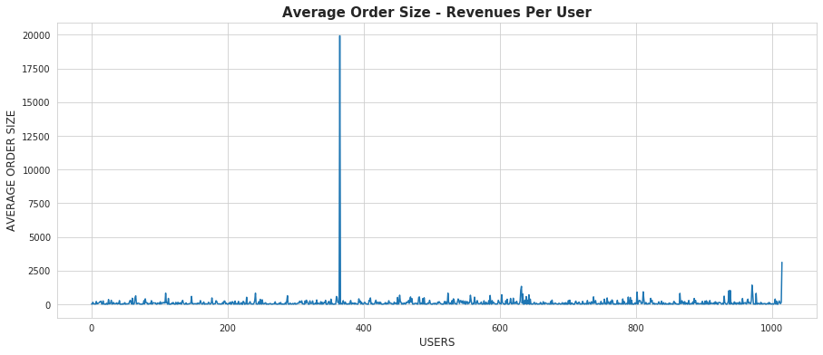

```python
# Plotting a graph of revenue per user
sns.set_style("whitegrid")

fig,ax=plt.subplots(figsize=(15,6))
x_values = pd.Series(range(0,len(orders['revenue'])))
ax.plot(x_values,orders['revenue'])

ax.set_title("Average Order Size - Revenues Per User", fontsize=15, fontweight="bold")
ax.set_xlabel('USERS', fontsize=12)
ax.set_ylabel('AVERAGE ORDER SIZE', fontsize=12)
```

```python
# Calculating the 95th and 99th percentiles with np.percentile method
np.percentile(orders['revenue'], [95, 99])
```

```
array([414.275, 830.3  ])
```

- As we can see, by examining the graph, The majority of users have an average order size of less than 1000.
- We can see two extreme points, one at 20000 (380 users) and the second at around 3000 (1000+ users), I'm assuming these orders belong to group B.
- Based in the perventile method we can see that not more than 5% of orders cost more than 414.275, and not more than 1% cost more than 830.3.
- Based on the graph and the percentiles results I will define more than 830 as outliers. setting 99% as the limit.

#### Filtering the data:

#### First I'll start with creating a dataset of outliers: 1) users with more than 2 orders. 2) users with orders that are more than 830 order size.

```python
#----Abnormal Users----#

# Creating a data of users with many orders
users_many_orders = pd.concat([orders_users_A[orders_users_A['orders'] > 2]['userId'],
                               orders_users_B[orders_users_B['orders'] > 2]['userId']], axis = 0)
users_many_orders #test

# Creating a data of users with expensive orders
users_expensive_orders = orders[orders['revenue'] > 830]['visitorId']
users_expensive_orders #test

# Combining the two abnoraml datasets and dropping duplicates
abnormal_users = pd.concat([users_many_orders, users_expensive_orders], axis = 0).drop_duplicates().sort_values()
abnormal_users #test
print('The total abnormal users are:' , abnormal_users.shape[0])
```

```
The total abnormal users are: 19
```

#### We have 19 abnormal users in total, I'll filter out the outliers, run the test again and see how the abnormal users affected the results.

```python
#----Filtering The Data----#

# filtering abnormal users from both groups and calculating the conversion

filtered_conversion_sample_A = pd.concat([orders_users_A[np.logical_not(orders_users_A['userId'].isin(abnormal_users))]['orders'],
                               pd.Series(0, index=np.arange(visits[visits['group']=='A']['visits'].sum()
                                                            - len(orders_users_A['orders'])),name='orders')],axis=0)

filtered_conversion_sample_A #test

filtered_conversion_sample_B = pd.concat([orders_users_B[np.logical_not(orders_users_B['userId'].isin(abnormal_users))]['orders'],
                               pd.Series(0, index=np.arange(visits[visits['group']=='B']['visits'].sum()
                                                            - len(orders_users_B['orders'])),name='orders')],axis=0)

filtered_conversion_sample_B #test

# Checking the length of each group
print(len(filtered_conversion_sample_B))
print(len(filtered_conversion_sample_A))
```

```
18909
18724
```

#### The samples size is not equal, I will sample the same size for both groups by comaring sample B (18909) to sample A (18724)

```python
# Comparing the size of group B to group A
filtered_conversion_sample_B = filtered_conversion_sample_B.sample(n=18724, replace = False, random_state = 0)
print(len(filtered_conversion_sample_B))
print(len(filtered_conversion_sample_A))
```

```
18724
18724
```

#### Null Hypothesis: There isn't a statistical significant difference in conversion between the groups using filtered data.

#### Alternative Hypothesis: There is a statistical significant difference in conversion between the groups using filtered data.

```python
# Finding the statistical sigificance

alpha = 0.05 #significance level

# calculating the p-value
p_value = stats.mannwhitneyu(filtered_conversion_sample_A, filtered_conversion_sample_B)[1]

print("P VALUE: {0:.3f}".format(p_value))
if (p_value < alpha):
    print("Null hypothesis rejected: the difference is statistically significant")
else:
    print("Failed to reject the null hypothesis: we can't make conclusions about the difference")

# calculating the relative conversion gain for group B
print("The relative conversion gain for group B: {0:.3f}".format(filtered_conversion_sample_B.mean()/filtered_conversion_sample_A.mean()-1))
```

```
P VALUE: 0.002
Null hypothesis rejected: the difference is statistically significant
The relative conversion gain for group B: 0.200
```

### Conclusion - Find the statistical significance of the difference in conversion between the groups using the filtered data.

- In order to find the statistical significance in conversion between the groups using the filtered data, I did the following:
  - Found out what are the outliers based on the average order size. I plotted a graph of the revenue to examine the changes and used the np.percentile method and found out that users with more than 830 are outliers, the limit was 99%.
  - I created a dataset with abnormal users using two conditions for outliers: 1) users with more than 2 orders. 2) users with orders that are more than 830 order size.
  - I filtered the data by removing the outliers, divided the data to the groups, and calculated the conversion rate of the filtered data.
  - I created an equal sample size for each group.
  - I ran the Mann-Whitney test, the same way I did with the raw data.
- After running the test for the filtered data, we can see that the p-value is 0.002, it's significantly lower than the significance level (0.05) which means that we can reject the null hypothesis.
- There is a statistically significant difference in conversion between the two groups.
- The p-value of the groups using raw data was 0.004, however, this difference is negligible, and we can say that even when we filtered the data from abnormal values/users, there is still a significant difference in conversion and the variance is still decreased.
- The relative conversion gain for group B is 20%, in the raw data test results it was a 16.7% relative gain, which means, the relative conversion gain, without the abnormal amount of orders, was still higher for group B than group A.
- Filtering out the outliers still proved to us that there is a difference in conversion between two groups and the results almost didn't change, And the gain for group B got even higher - The outliers didn't affect that much on the test and its results.
- Group B is much better than group A with or without outliers.

### Find the statistical significance of the difference in average order size between the groups using the filtered data. Make conclusions and conjectures.

```python
# Calculating average order size for each group

filtered_revenue_sample_A = orders[np.logical_and(
        orders['group']=='A',
        np.logical_not(orders['visitorId'].isin(abnormal_users)))]['revenue']
filtered_revenue_sample_A # test

filtered_revenue_sample_B = orders[np.logical_and(
        orders['group']=='B',
        np.logical_not(orders['visitorId'].isin(abnormal_users)))]['revenue']
filtered_revenue_sample_B # test
```

```
0        30.4
1        15.2
3       155.1
4        40.5
5        35.0
        ...
1181    390.5
1186    240.6
1190    135.3
1191    255.7
1192    100.8
Name: revenue, Length: 537, dtype: float64
```

```python
# Checking the length of each group
print(len(filtered_revenue_sample_B))
print(len(filtered_revenue_sample_A))
```

```
537
446
```

#### The samples size is not equal, I will sample the same size for both groups by comaring sample B (537) to sample A (446)

```python
# Comparing the size of group B to group A
filtered_revenue_sample_B = filtered_revenue_sample_B.sample(n=446, replace = False, random_state = 0)
print(len(filtered_revenue_sample_B))
print(len(filtered_revenue_sample_A))
```

```
446
446
```

#### Null Hypothesis: There isn't a statistical significant difference in average order size between the groups using filtered data.

#### Alternative Hypothesis: There is a statistical significant difference in average order size between the groups using filtered data.

```python
# Finding the statistical sigificance

alpha = 0.05 #significance level

# calculating the p-value
p_value = stats.mannwhitneyu(filtered_revenue_sample_A, filtered_revenue_sample_B)[1]

print("P VALUE: {0:.3f}".format(p_value))
if (p_value < alpha):
    print("Null hypothesis rejected: the difference is statistically significant")
else:
    print("Failed to reject the null hypothesis: we can't make conclusions about the difference")

# calculating the relative gain for group B
print("The relative gain for group B: {0:.3f}".format(filtered_revenue_sample_B.mean()/filtered_revenue_sample_A.mean()-1))
```

```
P VALUE: 0.385
Failed to reject the null hypothesis: we can't make conclusions about the difference
The relative gain for group B: 0.001
```

### Conclusion - Find the statistical significance of the difference in average order size between the groups using filtered data.

- In order to find the statistical significance, I did the following:
  - I filtered the data by removing the outliers, divided the data to the groups, and calculated the conversion rate of the filtered data.
  - I created an equal sample size for each group.
  - I ran the Mann-Whitney test, the same way I did with the raw data.
- After running the test, we can see that the p-value of these two samples is 0.385, it's significantly higher than the significance level (0.05) which means that we can't reject the null hypothesis.
- The groups' average order size differences are yet to be determined, we can't make conclusions about the difference.
- The relative gain for group B is 0.1%! we can say that there wasn't gain at all, which means the outliers indeed affected the gain for group B, the higher revenue of the expensive orders was affecting the gain/the advantage of group B over group A.
- The p-value for both tests, with and without outliers is pretty close (0.385 - 0.45), both results determined that we can't make conclusions about the difference and we can't reject the null hypothesis.
- I'm assuming that without the outliers, group B lost all the advantages/lead compare to group A, and the relative gain was affected by the outliers from (35.9% gain to 0.1%)
- These two tests dispute my assumption that group B did better than group B by the average order size, cause even though based on the graph of average order size group B looked significantly better, with and without the outliers we are yet to say that there's a difference and group B did better.

# Make a decision based on the test results:

**After analyzing the test, here's what I've found:**

- According to both the raw and the filtered data, There's a statistically significant difference in conversion between the groups.
- According to the raw data, we can't assume that there is a statistically significant difference in average order size between the groups.
- After removing the outliers, the filtered data as well didn't reveal any statistically significant differences in average order size between the groups.
- The graph of the difference in conversion between the groups shows that group B's results are better than those of group A, and stabilized at the end.
- The graph showing the difference in average order size between the groups shows that in some parts group B's results are better than group A, however, it is fluctuated and not stable and therefore, we can draw any definite conclusion.
- Based on the test results:
  - Group B did better than group A in conversion rates.
  - we can't prove that group B did better than group B in average order size even if the graph shows a few spikes in the relative gain for group B as opposed to group A.

**My recommendation to the company:**

- First of all based on the data I was given, I would do the test again with a proper data - that has equal sample sizes to begin with - one of the criteria for a powerful and accurate A/B test is that the number of users in different groups doesn't vary by more than 1%. I received a dataset with more than a 1% difference in the number of users between the groups.
- Based on the conversion graph and test, I would recommend the company to stop the test. Group B scored higher in both raw and filtered data and the difference was statistically significant and also, the graph of the relative conversion gain and the conversion rate for both groups showed that the conversion is stable.
- Based on the average order size, I would recommend the company to stop the test. we can't determine there's a statistically significant difference in average order size between the two groups and based on the graphs and the test there is a low chance that the improvement will bring us the higher size of the average order.
- In conclusion, Overall, I would recommend the company to stop the test, and if it's possible to run the test again with a better data source and see f that changes the picture.